# Assignment 1

Angela Wong

## Introduction:

The answers to the Interpret questions are in **bold syntax** in the document. I selected the dataset GSE114260, named “Effect of estrogen (E2) treatment on the C4-12 relative to the MCF7 cells” from a 2018 paper [“ERα-mediated cell cycle progression is an important requisite for CDK4/6 inhibitor response in HR+ breast cancer”](https://pubmed.ncbi.nlm.nih.gov/29963233/), written by Petrossian et al. for this assignment. **I chose this dataset because I did an assignment on the effects of estrogen receptors in Alzheimer’s Disease last semester, and I will be doing a cancer related project in the coming summer. I wanted to continue on the topic of estrogen receptors and estrogen treatment and dins a dataset that would combine that with cancer.**

In the GEO page for this study, there were two file that was linked to the paper. The dataset I choose had combined data from MCF-7, and the other only had the data for the new variants (C4-12ERaERE) that the authors used.

## Data Downloading and Setup:

```r
if (!requireNamespace("BiocManager", quietly = TRUE))
    install.packages("BiocManager")
if (!requireNamespace("GEOquery", quietly = TRUE))
    BiocManager::install("GEOquery")
if (!requireNamespace("edgeR", quietly = TRUE))
    BiocManager::install("edgeR")
if (!requireNamespace("limma", quietly = TRUE))
    BiocManager::install("limma")
if (!requireNamespace("biomaRt", quietly = TRUE))
    BiocManager::install("biomaRt")
if (!requireNamespace("ggplot2", quietly = TRUE))
    install.packages("ggplot2")

# AnnotationDBi, org.Hs.eg.db, and EnsDb.Hsapiens.v79 were later used to add
# Ensembl IDs to the dataset
if (!requireNamespace("AnnotationDbi", quietly = TRUE))
    BiocManager::install("AnnotationDbi")
if (!requireNamespace("org.Hs.eg.db", quietly = TRUE))
    BiocManager::install("org.Hs.eg.db")
if (!requireNamespace("EnsDb.Hsapiens.v79", quietly = TRUE))
    BiocManager::install("EnsDb.Hsapiens.v79")
```

```r
# get supplementary files and name of file of interest
if (!dir.exists("GSE114260")) {
  dataFiles <- GEOquery::getGEOSuppFiles("GSE114260",
                                         filter_regex = "GSE114260_combined_unstranded_read_counts")
  fileName <- rownames(dataFiles)
} else {
  fileName <- "GSE114260_combined_unstranded_read_counts.txt.gz"
}

# open file of interest
initialData <- read.delim(fileName, header = TRUE, check.names = FALSE)
```

## Cleaning the Data and Mapping to HUGO symbols:

The dataset contains:

```r
dim(initialData)
```

```
## [1] 23393    19
```

**The first column is the symbol of each gene, and the other 18 columns are the samples. The newly added samples that are named C4-12ERaERE are cell lines that lack ER and transfected with ERaERE. There’s 3 control and 3 E2 treated.**

```r
colnames(initialData)
```

```
##  [1] "symbol"                "C4.12ERaERE_control.1" "C4.12ERaERE_control.2"
##  [4] "C4.12ERaERE_control.3" "C4.12ERaERE_E2.1"      "C4.12ERaERE_E2.2"
##  [7] "C4.12ERaERE_E2.3"      "DMSO_1"                "DMSO_2"
## [10] "DMSO_3"                "E2_1"                  "E2_2"
## [13] "E2_3"                  "E2Paro_1"              "E2Paro_2"
## [16] "E2Paro_3"              "Paroxetine_1"          "Paroxetine_2"
## [19] "Paroxetine_3"
```

The first 6 rows of the dataset are displayed below as an overview of the data structure.

```r
head(initialData)
```

|  | symbol | C4.12ERaERE_control.1 | C4.12ERaERE_control.2 | C4.12ERaERE_control.3 | C4.12ERaERE_E2.1 | C4.12ERaERE_E2.2 | C4.12ERaERE_E2.3 | DMSO_1 | DMSO_2 | DMSO_3 | E2_1 | E2_2 | E2_3 | E2Paro_1 | E2Paro_2 | E2Paro_3 | Paroxetine_1 | Paroxetine_2 | Paroxetine_3 |
| --- | --- | --- | --- | --- | --- | --- | --- | --- | --- | --- | --- | --- | --- | --- | --- | --- | --- | --- | --- |
| 1 | A1BG | 260 | 242 | 288 | 244 | 229 | 243 | 400 | 564 | 498 | 279 | 269 | 279 | 182 | 162 | 337 | 346 | 327 | 358 |
| 2 | A1BG-AS1 | 130 | 155 | 154 | 152 | 149 | 180 | 278 | 337 | 253 | 179 | 180 | 185 | 99 | 96 | 185 | 201 | 202 | 208 |
| 3 | A1CF | 4 | 5 | 2 | 3 | 1 | 5 | 0 | 1 | 1 | 2 | 1 | 0 | 0 | 2 | 2 | 2 | 3 | 2 |
| 4 | A2M | 6 | 2 | 3 | 2 | 3 | 2 | 20 | 18 | 27 | 11 | 11 | 9 | 26 | 22 | 37 | 93 | 88 | 81 |
| 5 | A2M-AS1 | 70 | 42 | 54 | 42 | 60 | 56 | 54 | 68 | 62 | 29 | 21 | 27 | 15 | 12 | 23 | 38 | 30 | 31 |
| 6 | A2ML1 | 9 | 7 | 10 | 5 | 10 | 7 | 0 | 1 | 1 | 3 | 1 | 0 | 1 | 1 | 1 | 2 | 1 | 0 |

Since the total number of rows (with each row a separate gene) equal to the number of unique gene symbols, there are no gene duplicates in this dataset.

```r
nrow(initialData) == length(unique(initialData$symbol))
```

```
## [1] TRUE
```

I then filtered out the genes with low counts. The code is adapted from the Lecture 4 slides. **In the end, 8,280 outlier genes were filtered out. There are 18 samples in this dataset, with 3 replicates per group.**

```r
# translate out the counts into counts per million (edgeR)
cpms = edgeR::cpm(initialData[, 2:19])
rownames(cpms) <- initialData[, 1]

# get rid of low counts
# n = 3 since there are 3 replicates per group
keep = rowSums(cpms > 1) >= 3
filtered_initalData = initialData[keep, ]
dim(filtered_initalData)
```

```
## [1] 15113    19
```

Before I mapped the genes to their HGNC symbols, I wanted to find the Ensembl ID of the genes first. The dataset does not have the Ensembl ID for the genes, so I will convert the gene symbols listed in the first column to its respective Ensembl ID and add it to the dataset. I set the row names to the gene’s corresponding Ensembl ID. When I was trying to map the gene symbols to the Ensemble ID, At first I thought that the *symbol* column contained the names of the genes, but after going through some entries while trying to find their Ensembl ID, I noticed that there were quite a few symbols that could not match using “org.Hs.eg.db”, so I mapped the symbols again using “EnsDb.Hsapiens.v79” and merged the two character vectors. I then created a new column for the IDs. The code is partly adapted from Arup Ghosh’s on [biostars](https://www.biostars.org/p/430015/). In addition, I found out that the dataset already has the correct HGNC/HUGO symbols under the *symbol* column, so I changed the row names to the symbols and removed the *symbol* column.

```r
library("org.Hs.eg.db")
library("EnsDb.Hsapiens.v79")

# the Ensembl IDs from org.Hs.eg.db
filtered_initalData$orgHsIDs <- mapIds(org.Hs.eg.db,
                    keys=filtered_initalData$symbol,
                    column="ENSEMBL",
                    keytype="SYMBOL",
                    multiVals="first")

# the Ensembl IDs from EnsDb.Hsapiens.v79
filtered_initalData$ensDbID <- mapIds(EnsDb.Hsapiens.v79,
                    keys=filtered_initalData$symbol,
                    keytype="SYMBOL",
                    multiVals="first")

# merge the two, add the merged column to the front and remove the old
filteredData <- cbind(ensembl_ID = dplyr::coalesce(filtered_initalData$ensDbID,
                                                   filtered_initalData$orgHsIDs),
                      filtered_initalData)

# change row names into the HUGO symbols
rownames(filteredData) <- filteredData$symbol

# remove the redundant columns
filteredData <- within(filteredData, rm("symbol", "ensDbID", "orgHsIDs"))
```

However, there were still some unmatched symbols because the symbols on the dataset were an alias. Thus, I isolated the gene symbols that had NA and tried to correct their symbols.

```r
# locate and identify the symbols with NA ID
allNA <- rownames(filteredData)[which(is.na(filteredData$ensembl_ID))]

# change from alias to symbol and map to ensembl ID again
for (sym in allNA) {
  temp_symbol <- limma::alias2Symbol(sym, species = "Hs")

  # if there is a corresponding symbol and it's not in the current dataset
  if (!identical(temp_symbol, character(0)) &&
      !(temp_symbol %in% rownames(filteredData))) {

    # change the alias to correct symbol
    rownames(filteredData)[rownames(filteredData) == sym] <- temp_symbol

    # try re-mapping Ensembl ID using EnsDb.Hsapiens.v79
    filteredData[temp_symbol, "ensembl_ID"] <- mapIds(EnsDb.Hsapiens.v79,
                                                      keys=temp_symbol,
                                                      keytype="SYMBOL",
                                                      multiVals="first")

    # if EnsDb.Hsapiens.v79 does not have the corresponding ID
    if (is.na(filteredData[temp_symbol, "ensembl_ID"])) {
      filteredData[temp_symbol, "ensembl_ID"] <- mapIds(org.Hs.eg.db,
                                                      keys=temp_symbol,
                                                      column="ENSEMBL",
                                                      keytype="SYMBOL",
                                                      multiVals="first")
    }
  }
}
```

**Since the HUGO symbols were part of the original dataset, I did not encounter issues with the expression values unable to match the HUGO symbols. However, I did have some symbols that were unable to map to a Ensembl ID. After googling a few of the symbols without an ID, I found that some were uncharacterized genes, which may have been the problem. For those genes, the symbol listed was also not its HUGO symbol. I tried checking the symbols with “TxDb.Hsapiens.UCSC.hg19.knownGene”, which was the source the authors used to annotate the data in the paper, but that did not work because “TxDb.Hsapiens.UCSC.hg19.knownGene” contained only “GENEID” and not “SYMBOL”. Thus, for those genes, I decided to leave them unchanged.**

```r
# the number of unmatched
sum(is.na(filteredData$ensembl_ID))
```

```
## [1] 175
```

```r
# the percentage of the dataset that have issues with mapping to IDs
(sum(is.na(filteredData$ensembl_ID)) / nrow(filteredData)) * 100
```

```
## [1] 1.157943
```

After cleaning, adding the HUGO symbols, and mapping the ensembl ID, the dataset looks like this:

```r
dim(filteredData)
```

```
## [1] 15113    19
```

```r
tail(filteredData)
```

|  | ensembl_ID | C4.12ERaERE_control.1 | C4.12ERaERE_control.2 | C4.12ERaERE_control.3 | C4.12ERaERE_E2.1 | C4.12ERaERE_E2.2 | C4.12ERaERE_E2.3 | DMSO_1 | DMSO_2 | DMSO_3 | E2_1 | E2_2 | E2_3 | E2Paro_1 | E2Paro_2 | E2Paro_3 | Paroxetine_1 | Paroxetine_2 | Paroxetine_3 |
| --- | --- | --- | --- | --- | --- | --- | --- | --- | --- | --- | --- | --- | --- | --- | --- | --- | --- | --- | --- |
| ZXDC | ENSG00000070476 | 2246 | 2238 | 2471 | 2403 | 2606 | 2841 | 1992 | 2456 | 2361 | 1764 | 1581 | 1641 | 1308 | 1281 | 2232 | 2277 | 2290 | 2207 |
| ZYG11A | ENSG00000203995 | 536 | 454 | 533 | 534 | 479 | 574 | 243 | 280 | 253 | 358 | 406 | 371 | 237 | 279 | 422 | 332 | 362 | 362 |
| ZYG11B | ENSG00000162378 | 2909 | 2616 | 2676 | 2808 | 3050 | 3314 | 820 | 884 | 846 | 774 | 758 | 741 | 400 | 406 | 694 | 626 | 624 | 675 |
| ZYX | ENSG00000159840 | 5923 | 5581 | 5843 | 6667 | 6865 | 6744 | 3829 | 4876 | 4509 | 1862 | 1960 | 1940 | 2475 | 2391 | 4364 | 5041 | 4812 | 5400 |
| ZZEF1 | ENSG00000074755 | 3455 | 3305 | 3718 | 3752 | 4215 | 4651 | 2453 | 3071 | 2901 | 2194 | 1972 | 2049 | 1792 | 1764 | 3049 | 3065 | 2886 | 3173 |
| ZZZ3 | ENSG00000036549 | 4117 | 3859 | 3935 | 3857 | 4400 | 4362 | 1747 | 1835 | 1759 | 2046 | 2072 | 1972 | 1647 | 1690 | 2636 | 2554 | 2734 | 2529 |

## Normalization:

To normalize my dataset, I used log2 on the counts per million to generate a box plot and used Trimmed Mean of M-values (TMM) normalization. The following code adapted from the Lecture 4 slides.

```r
filtered_data_matrix <- as.matrix(filteredData[,2:19])
rownames(filtered_data_matrix) <- rownames(filteredData)

samples <- colnames(filteredData)[2:19]

edgeRExp <- edgeR::DGEList(filtered_data_matrix, group = samples)
normalized <- edgeR::calcNormFactors(edgeRExp)
normalized <- edgeR::estimateDisp(normalized)
```

```
## Design matrix not provided. Switch to the classic mode.
```

```r
logNormalized <- edgeR::cpm(normalized, log = T)
```

### Box plot:

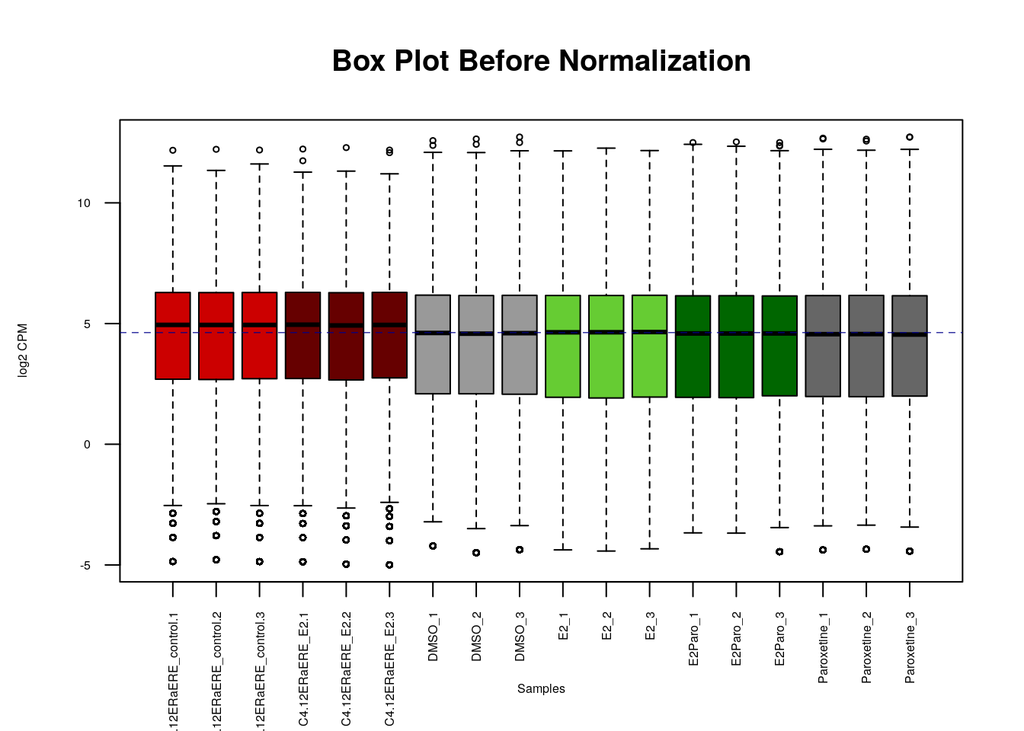

```r
data2plot <- log2(edgeR::cpm(filteredData[,2:ncol(filteredData)]))

# set colour scheme so that the three replicates in each group would have the
# same colour.
plotColours <- rep(c("#CC0000", "#660000", "#999999", "#66CC33", "#006600",
                     "#666666"), each = 3)

# Before normalization
boxplot(data2plot, xlab = "Samples", ylab = "log2 CPM", las = 2, cex = 0.5,
        cex.lab = 0.5, cex.axis = 0.5, main = "Box Plot Before Normalization",
        col = plotColours)

# draw the median on each box plot
abline(h = median(apply(data2plot, 2, median)), col = "darkblue", lwd = 0.6,
       lty = "dashed")
```

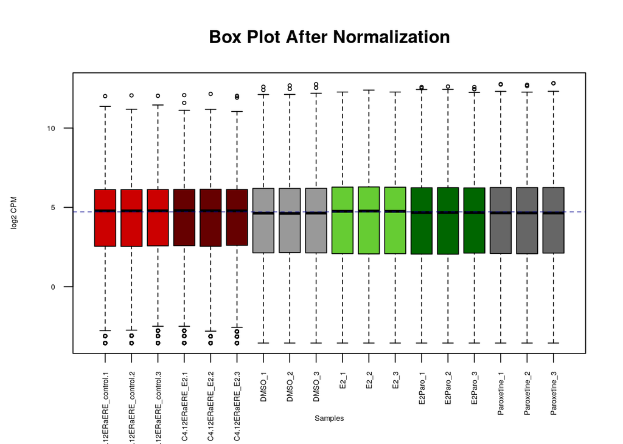

```r
# After Normalization
boxplot(logNormalized, xlab = "Samples", ylab = "log2 CPM", las = 2, cex = 0.5,
        cex.lab = 0.5, cex.axis = 0.5, main = "Box Plot After Normalization",
        col = plotColours)

# draw the median on each box plot
abline(h = median(apply(logNormalized, 2, median)), col = "darkblue", lwd = 0.6,
       lty = "dashed")
```

### Density plot:

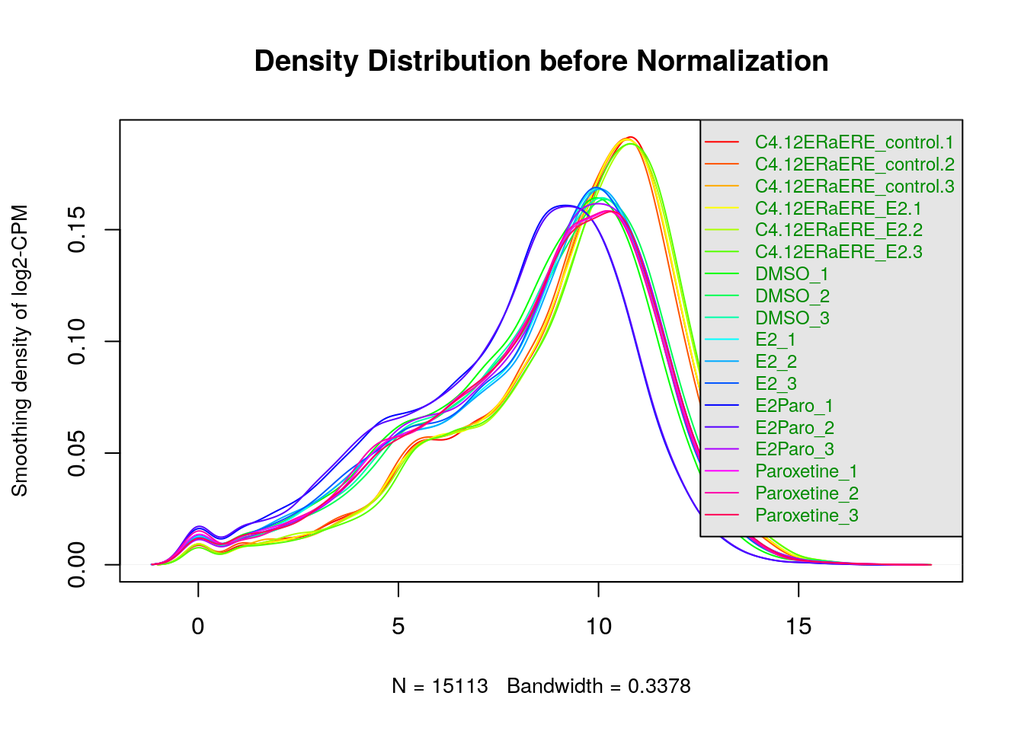

```r
# before normalization
counts_density <- apply(log2(filteredData[,2:ncol(filteredData)]), 2, density)

  #calculate the limits across all the samples
    xlim <- 0; ylim <- 0
    for (i in 1:length(counts_density)) {
      xlim <- range(c(xlim, counts_density[[i]]$x));
      ylim <- range(c(ylim, counts_density[[i]]$y))
    }
    cols <- rainbow(length(counts_density))
    ltys <- rep(1, length(counts_density))

    #plot the first density plot to initialize the plot
    plot(counts_density[[1]], xlim=xlim, ylim=ylim, type="n",
         ylab="Smoothing density of log2-CPM",cex.lab = 0.85,
         main = "Density Distribution before Normalization")

    #plot each line
    for (i in 1:length(counts_density)) lines(counts_density[[i]], col=cols[i], lty=ltys[i])

    #create legend
    legend("topright", colnames(data2plot),
           col=cols, lty=ltys, cex=0.75,
           border ="blue",  text.col = "green4",
           merge = TRUE, bg = "gray90")
```

[figure not shown]

```r
# after normalization
counts_density <- apply(logNormalized, 2, density)

  #calculate the limits across all the samples
    xlim <- 0; ylim <- 0
    for (i in 1:length(counts_density)) {
      xlim <- range(c(xlim, counts_density[[i]]$x));
      ylim <- range(c(ylim, counts_density[[i]]$y))
    }
    cols <- rainbow(length(counts_density))
    ltys <- rep(1, length(counts_density))

    #plot the first density plot to initialize the plot
    plot(counts_density[[1]], xlim=xlim, ylim=ylim, type="n",
         ylab="Smoothing density of log2-CPM",cex.lab = 0.85,
         main = "Density Distribution before Normalization")

    #plot each line
    for (i in 1:length(counts_density)) lines(counts_density[[i]], col=cols[i], lty=ltys[i])

    #create legend
    legend("topright", colnames(data2plot),
           col=cols, lty=ltys, cex=0.75,
           border ="blue",  text.col = "green4",
           merge = TRUE, bg = "gray90")
```

### MDS plot:

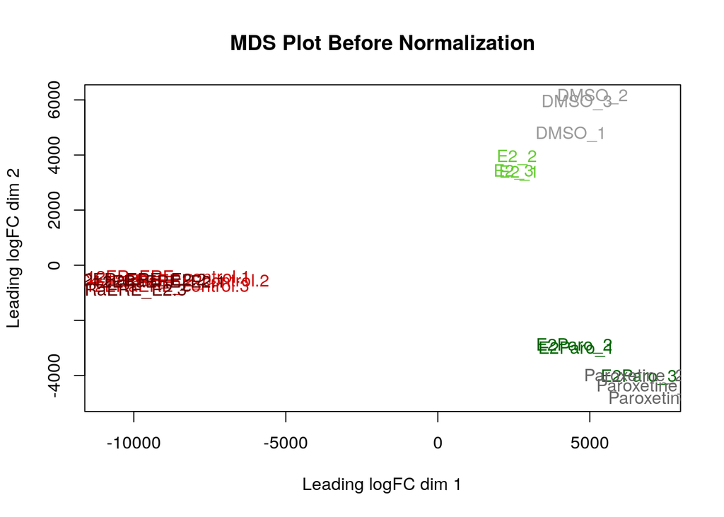

```r
# MDS before normalization
limma::plotMDS(filteredData[2:19], col = plotColours, main =
                 "MDS Plot Before Normalization")
```

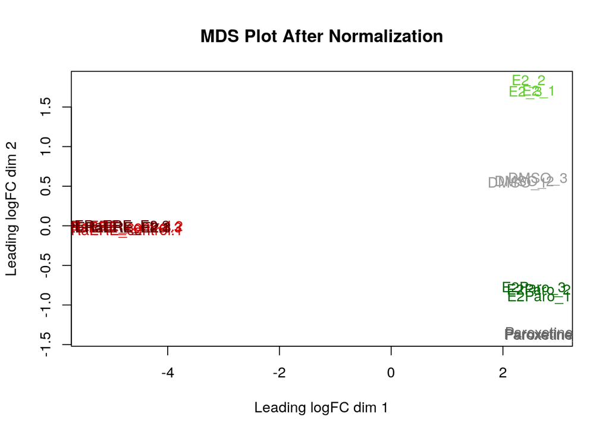

```r
# MDS after normalization
limma::plotMDS(logNormalized, col = plotColours, main =
                 "MDS Plot After Normalization")
```

## Final Coverage of Dataset:

**After filtering and normalization, my final dataset consists of 15,113 distinct genes for 18 samples (6 groups of 3 replicates each). It contains 2 cell lines: MCF-7/MCF-7aro and C4-12ERaERE. It orginally contained 23,393 genes. A total of 8,280 outliers were filtered out, and there were 175 genes that could not be matched to a Ensembl ID. The dataset was already mapped to HUGO symbols before I cleaned it.**

```r
dim(logNormalized)
```

```
## [1] 15113    18
```

```r
head(logNormalized)
```

```
##          C4.12ERaERE_control.1 C4.12ERaERE_control.2 C4.12ERaERE_control.3
## A1BG                  3.009701             2.9855511             3.1627617
## A1BG-AS1              2.024955             2.3515384             2.2715737
## A2M                  -1.891679            -2.7335357            -2.4900378
## A2M-AS1               1.157650             0.5314128             0.8062813
## A2MP1                -3.104632            -3.5461157            -3.5461157
## A4GALT                2.309925             2.4742874             2.5471607
##          C4.12ERaERE_E2.1 C4.12ERaERE_E2.2 C4.12ERaERE_E2.3    DMSO_1
## A1BG             2.921075         2.753827        2.7887673 4.4548678
## A1BG-AS1         2.248101         2.143589        2.3620498 3.9324220
## A2M             -2.766222        -2.532415       -2.8182868 0.2361596
## A2M-AS1          0.459023         0.872188        0.7297896 1.6015397
## A2MP1           -3.546116        -3.546116       -3.5461157 3.7686555
## A4GALT           2.534572         2.890231        2.6536355 4.9514731
##              DMSO_2    DMSO_3       E2_1       E2_2       E2_3  E2Paro_1
## A1BG      4.6829163 4.6287727  3.8705472  3.7813566  3.9020688 3.9284910
## A1BG-AS1  3.9432049 3.6565905  3.2349512  3.2061818  3.3135205 3.0568375
## A2M      -0.1477696 0.5082164 -0.6018284 -0.6340310 -0.8234152 1.1690014
## A2M-AS1   1.6654804 1.6576528  0.6754212  0.2045694  0.6079504 0.4151797
## A2MP1     3.7906748 3.7012027  0.1737551  0.4388570  0.4481195 2.3905073
## A4GALT    5.0852232 4.9985554  6.1617482  6.1964245  6.1113001 6.6365989
##           E2Paro_2  E2Paro_3 Paroxetine_1 Paroxetine_2 Paroxetine_3
## A1BG     3.7562567 4.0348890     4.151594    4.0920959    4.1551566
## A1BG-AS1 3.0076392 3.1758431     3.373022    3.4016349    3.3767710
## A2M      0.9328594 0.9075715     2.274907    2.2179158    2.0347040
## A2M-AS1  0.1113196 0.2612093     1.020147    0.7158086    0.6968662
## A2MP1    2.3852699 2.6393744     4.130696    4.0920959    4.1144835
## A4GALT   6.6142921 6.7650081     5.849135    5.7673813    6.0005957
```

## Citation:

1. Ghosh, A. (1969, March 1). Conversion of Gene Name to Ensembl ID. biostars. https://www.biostars.org/p/430015/.
2. Petrossian, K., Kanaya, N., Lo, C., Hsu, P.-Y., Nguyen, D., Yang, L., … Chen, S. (2018). ERα-mediated cell cycle progression is an important requisite for CDK4/6 inhibitor response in HR+ breast cancer. Oncotarget, 9(45), 27736–27751. https://doi.org/10.18632/oncotarget.25552